# Analysis of data from fitness tracking device

Harpratap Singh Layal

May 1, 2016

**Overview:** This project is analysis of activity data collected from a fitness tracker like a wearable or smart watch. The data contains the number of steps taken in 5 minute intervals throughout the day on the given dates.

## Part 1

*Pre imputation analysis of data for determining the acceptable and non-acceptable values in the given data.*

1. Total Number of records with missing values

```r
  dfrBad <- filter(dfrAct, (is.na(dfrAct$steps) | is.na(dfrAct$date) | is.na(dfrAct$interval) ))
  nrow(dfrBad)
```

```
## [1] 2304
```

2. Total number of records with missing values per day

```r
  data.frame(table(dfrBad$date))
```

```
##         Var1 Freq
## 1 2012-10-01  288
## 2 2012-10-08  288
## 3 2012-11-01  288
## 4 2012-11-04  288
## 5 2012-11-09  288
## 6 2012-11-10  288
## 7 2012-11-14  288
## 8 2012-11-30  288
```

## Part 2

1. Number of valid records across all days

```r
statusAct <- complete.cases(dfrAct)
dfrGood <- dfrAct[statusAct,]
nrow(dfrGood)
```

```
## [1] 15264
```

# Data Imputation

**Strategy:** Substitute the mean of the particular interval across all days for the missing data  
**Reason:** Mean of the steps taken in that particular time interval most likely represents the number of steps taken, as human behaviour is repetitive and we tend to do similar amount of activity in certain time of the day.

```r
dfrGood.GroupIntervalAvg <- summarize(group_by(dfrGood, interval), mean(steps))

dfrClean <- dfrAct %>%
            group_by(interval) %>%
            mutate(steps = replace(steps, is.na(steps), floor(mean(steps, na.rm = T))))
write.csv(dfrClean, "actclean.csv", row.names = F)
dfrCleaned <- read.csv("actclean.csv", header = T, stringsAsFactors = F)
```

2. Total number of steps taken across all days

```r
summarise(dfrCleaned, sum(steps))
```

```
##   sum(steps)
## 1     655736
```

3. Average number of steps taken across all days

```r
dfrAvgSteps <- summarize(group_by(dfrCleaned, date), mean(steps))
print(dfrAvgSteps)
```

```
## Source: local data frame [61 x 2]
##
##          date mean(steps)
##         (chr)       (dbl)
## 1  2012-10-01    36.94792
## 2  2012-10-02     0.43750
## 3  2012-10-03    39.41667
## 4  2012-10-04    42.06944
## 5  2012-10-05    46.15972
## 6  2012-10-06    53.54167
## 7  2012-10-07    38.24653
## 8  2012-10-08    36.94792
## 9  2012-10-09    44.48264
## 10 2012-10-10    34.37500
## ..        ...         ...
```

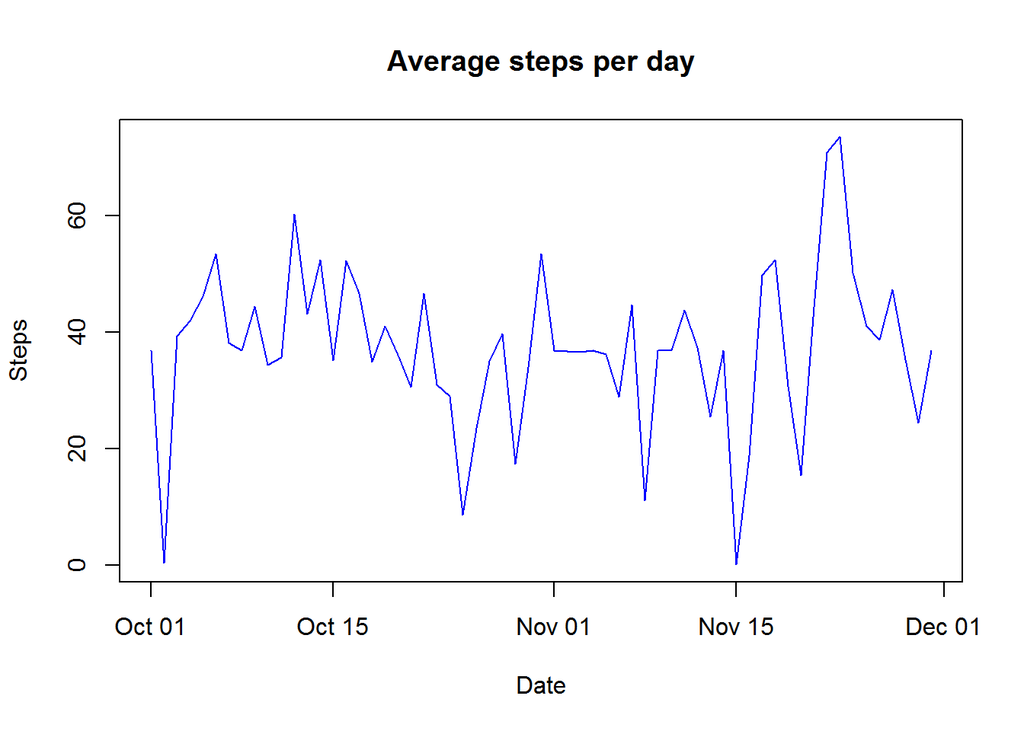

```r
plot(as.Date(dfrAvgSteps$date), dfrAvgSteps$`mean(steps)`, pch=1,type="l", col="blue",
       main="Average steps per day",
       xlab="Date",
       ylab="Steps")
```

4. 5-minute interval, across all the days containing the maximum number of steps

```r
dfrCleaned.MaxSteps <- dfrCleaned %>%
                arrange(desc(steps)) %>%
                head(1) %>%
                select(-date)
print(dfrCleaned.MaxSteps)
```

```
##   steps interval
## 1   806      615
```

5. 5-minute interval, across all the days containing the minimum number of steps

```r
MinSteps <- dfrCleaned %>%
            arrange(steps) %>%
            head(1) %>%
            select(-date,-interval)
IntMinSteps <- as.integer(MinSteps)
dfrCleaned.MinSteps <- filter(dfrCleaned, steps == IntMinSteps)
head(dfrCleaned.MinSteps)
```

```
##   steps       date interval
## 1     0 2012-10-01        5
## 2     0 2012-10-01       10
## 3     0 2012-10-01       15
## 4     0 2012-10-01       20
## 5     0 2012-10-01       30
## 6     0 2012-10-01       35
```

6. Number of valid records per day

```r
dfrValidRecords <- data.frame(table(dfrCleaned$date))
print(dfrValidRecords)
```

```
##          Var1 Freq
## 1  2012-10-01  288
## 2  2012-10-02  288
## 3  2012-10-03  288
## 4  2012-10-04  288
## 5  2012-10-05  288
## 6  2012-10-06  288
## 7  2012-10-07  288
## 8  2012-10-08  288
## 9  2012-10-09  288
## 10 2012-10-10  288
## 11 2012-10-11  288
## 12 2012-10-12  288
## 13 2012-10-13  288
## 14 2012-10-14  288
```

[output cut: 47 more lines]

7. Total number of steps taken per day

```r
dfrStepPerDay <- summarize(group_by(dfrCleaned, date), sum(steps))
print(dfrStepPerDay)
```

```
## Source: local data frame [61 x 2]
##
##          date sum(steps)
##         (chr)      (int)
## 1  2012-10-01      10641
## 2  2012-10-02        126
## 3  2012-10-03      11352
## 4  2012-10-04      12116
## 5  2012-10-05      13294
## 6  2012-10-06      15420
## 7  2012-10-07      11015
## 8  2012-10-08      10641
## 9  2012-10-09      12811
## 10 2012-10-10       9900
## ..        ...        ...
```

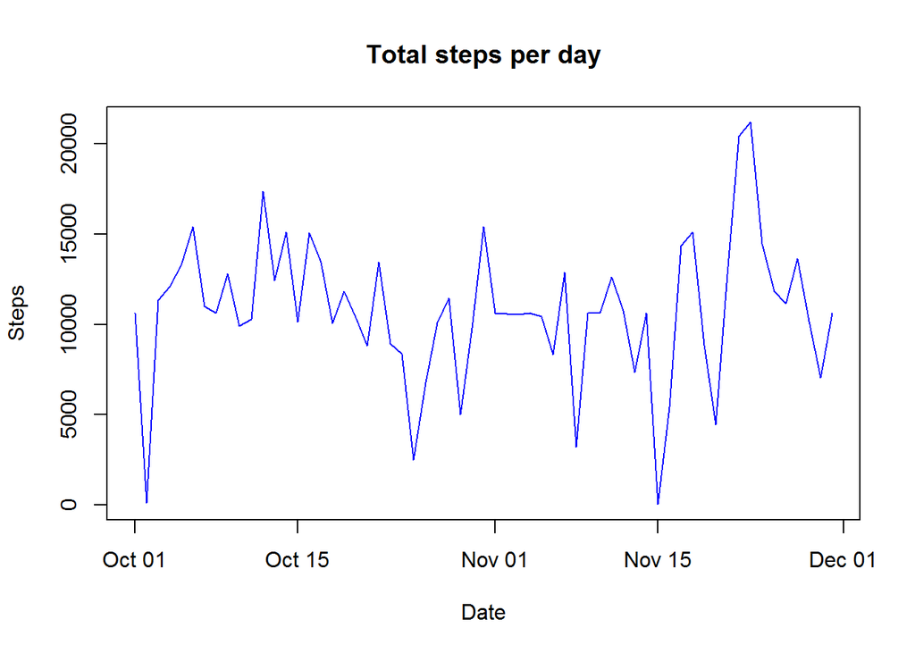

```r
plot(as.Date(dfrStepPerDay$date), dfrStepPerDay$`sum(steps)`, pch=1,type="l", col="blue",
       main="Total steps per day",
       xlab="Date",
       ylab="Steps")
```

8. Average number of steps taken per day

```r
dfrAvgSteps <- summarize(group_by(dfrCleaned, date), mean(steps))
avgStepsPerDay <- mean(dfrStepPerDay$`sum(steps)`)
print(avgStepsPerDay)
```

```
## [1] 10749.77
```

9. The day on which the individual walked the most

```r
dfrDayMostWalked <- dfrStepPerDay %>%
                        arrange(desc(`sum(steps)`)) %>%
                        head(1) %>%
                        select(date)
print(dfrDayMostWalked)
```

```
## Source: local data frame [1 x 1]
##
##         date
##        (chr)
## 1 2012-11-23
```

10. The day on which day the individual walked the least

```r
dfrDayLeastWalked <- dfrStepPerDay %>%
                      arrange(`sum(steps)`) %>%
                      head(1) %>%
                      select(date)
print(dfrDayLeastWalked)
```

```
## Source: local data frame [1 x 1]
##
##         date
##        (chr)
## 1 2012-11-15
```

# Summary Report

1. Impact of imputing missing data on total daily number of steps

```r
as.integer(summarise(dfrCleaned, sum(steps))) - as.integer(summarise(dfrGood, sum(steps)))
```

```
## [1] 85128
```

```r
as.integer(summarise(dfrCleaned, mean(steps))) - as.integer(summarise(dfrGood, mean(steps)))
```

```
## [1] 0
```

The total number of steps taken has increased overall due to imputation of data. But average remains the same, hence the data imputation strategy can be considered a good one as there is no change in the behaviour of the data.

2. Differences in activity pattern during weekdays and weekends

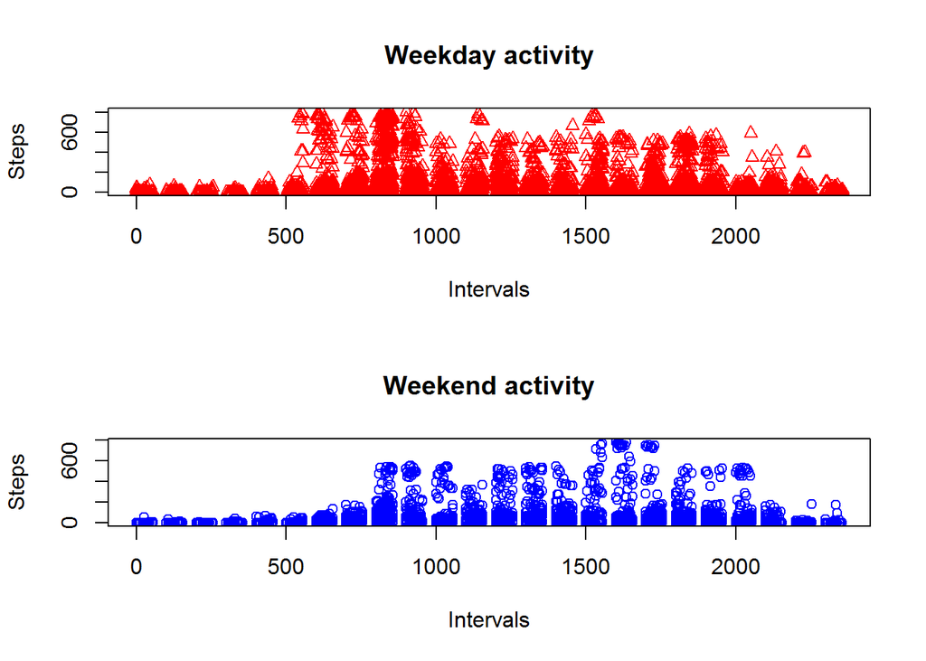

```r
dfrCleaned$week <- ifelse(weekdays(as.Date(dfrCleaned$date)) %in% c("Saturday","Sunday"), "weekend","weekday")
  dfrWeekday <- filter(dfrCleaned, week == "weekday")
  dfrWeekend <- filter(dfrCleaned, week == "weekend")
  par(mfrow=c(2,1))
  plot(dfrWeekday$interval, dfrWeekday$steps, pch=2, col="red",
       main="Weekday activity",
       xlab="Intervals",
       ylab="Steps")
  plot(dfrWeekend$interval, dfrWeekend$steps, pch=1, col="blue",
       main="Weekend activity",
       xlab="Intervals",
       ylab="Steps")
```